# DIFN_analysis_Ecosystems

Dec 11, 2020

# Load data

```r
setwd("~/../Shrubs-Seedlings/code/FireFootprints_analysis/")
load(file = "../../compiled_data/fire_footprints/DIFN_Ecosystems.Rdata")
```

# Make sure there are no repeats

```r
dfl %>%
  group_by(DIFN.53, shrubarea3) %>%
  filter(n()>1) %>%
  arrange(DIFN.53)
```

```
## # A tibble: 13 x 18
## # Groups:   DIFN.53, shrubarea3 [5]
##    Sdlg  Ht.cm Fire  FirePatch Elevation Slope.Deg Light_File ShrubSpp03 Cov1.3
##    <chr> <dbl> <chr> <chr>         <dbl>     <dbl>      <dbl> <chr>       <dbl>
##  1 95       72 AMRC  AMRC-2         1701        16         79 CECO         1080
##  2 96       50 AMRC  AMRC-2         1701        16         79 CECO         1080
##  3 85       68 AMRC  AMRC-2         1701        14         71 CECO          660
##  4 86       45 AMRC  AMRC-2         1701        14         71 CECO          660
##  5 87       72 AMRC  AMRC-2         1701        14         71 CECO          660
##  6 80       49 AMRC  AMRC-2         1701        15         68 CECO         1050
##  7 82       42 AMRC  AMRC-2         1701        15         68 CECO         1050
##  8 73       55 AMRC  AMRC-2         1672        21         64 CECO         1070
##  9 74       57 AMRC  AMRC-2         1672        21         64 CECO         1070
## 10 75       49 AMRC  AMRC-2         1672        21         64 CECO         1070
## 11 91       20 AMRC  AMRC-2         1701        16         77 ARPA         1140
## 12 92       11 AMRC  AMRC-2         1701        16         77 ARPA         1140
## 13 93       18 AMRC  AMRC-2         1701        16         77 ARPA         1140
## # ... with 9 more variables: Ht1.3 <dbl>, Years <dbl>, DIFN.53 <dbl>,
## #   ref <dbl>, Species <chr>, shrubarea3 <dbl>, Ht_cm2 <dbl>,
## #   Ht.cm.meanDIFN <dbl>, E_noyears <dbl>
```

# The true repeats are:

1. Seedlings 80/82
2. Seedlings 91/92/93
3. More

# Make a new data frame with only one row per DIFN measurement

```r
dfl_unique <- dfl %>%
  group_by(DIFN.53, shrubarea3) %>%
  mutate(Ht_cm_mean = mean(Ht_cm2)) %>%
  filter(Sdlg == min(Sdlg))
```

# Question 0: Why are there so many more rows of DIFN data than there are seedlings in the final data set?

```r
dfl_unique %>%
  filter(!Species %in% c("ABCO", "PIPO") | ref ==1) %>%
  group_by(Fire) %>%
  count()
```

```
## # A tibble: 5 x 2
## # Groups:   Fire [5]
##   Fire      n
##   <chr> <int>
## 1 AMRC     16
## 2 CLVD      5
## 3 FRDS     10
## 4 PLKN      2
## 5 STAR      7
```

There are about 200 trees in my Chapter 2 analysis. The extra trees here are non-PIPO/ABCO, reference shrub measurements, and trees that subsequently got thrown out of the analysis.

# Question 1: How does DIFN vary with species and along the chronosequence?

## Take out repeats

```r
dfl_unique <- dfl %>%
  filter(Ht.cm == min(Ht.cm))
```

```r
dfl_unique <- dfl_unique %>%
  mutate(ShrubSpp03 = case_when(
    ShrubSpp03 == "ARPA" ~ "Manzanita",
    ShrubSpp03 == "CECO" ~ "Whitethorn",
    ShrubSpp03 == "CEIN" ~ "Deerbrush",
    TRUE ~ "Other")
  )
```

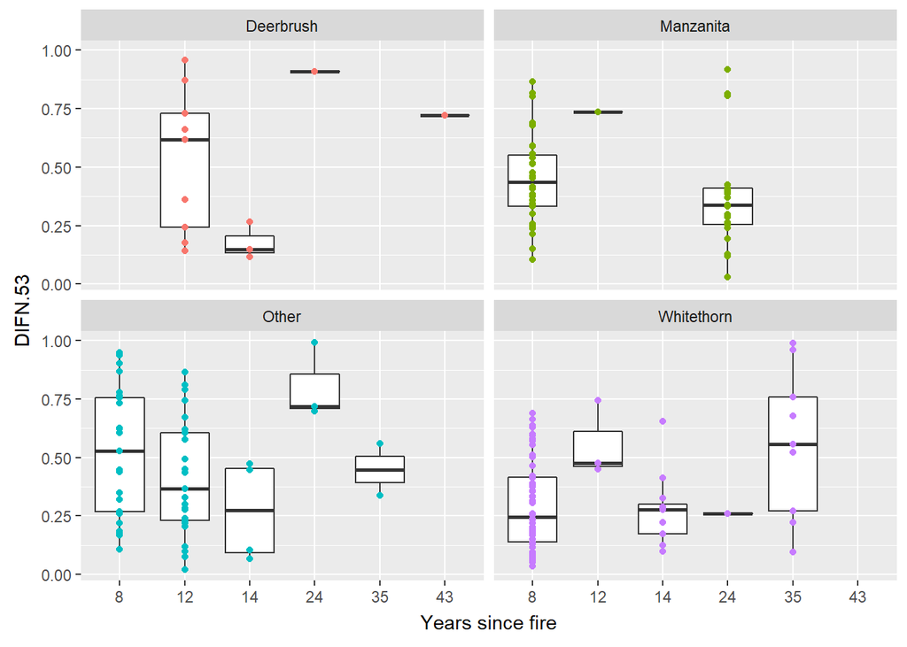

```r
ggplot(dfl_unique) +
  geom_boxplot(aes(x = as.factor(Years), y = DIFN.53)) +
  geom_point(aes(x = as.factor(Years), y = DIFN.53, col = ShrubSpp03)) +
  facet_wrap(~ ShrubSpp03)+
  theme(legend.position = "none")+
  xlab("Years since fire")
```

```r
ggsave("../../results/figures/DIFN/DIFN_reviewer_response.png")
```

## Model DIFN.53 in relation to shrubarea3, shrub species, height, and years since fire

```r
dfl_unique <- dfl_unique %>%
  mutate(ShrubSpp03 = as.factor(ShrubSpp03))
LM <- lm(DIFN.53 ~ shrubarea3 + ShrubSpp03 + Years + Ht.cm.meanDIFN, data = dfl)
summary(LM)
```

```
##
## Call:
## lm(formula = DIFN.53 ~ shrubarea3 + ShrubSpp03 + Years + Ht.cm.meanDIFN,
##     data = dfl)
##
## Residuals:
##     Min      1Q  Median      3Q     Max
## -0.5039 -0.1320 -0.0178  0.1196  0.5135
##
## Coefficients:
##                   Estimate Std. Error t value Pr(>|t|)
## (Intercept)      4.366e-01  4.016e-02  10.873  < 2e-16 ***
## shrubarea3      -3.004e-06  3.593e-07  -8.359 8.65e-15 ***
## ShrubSpp03CECO  -9.691e-02  3.336e-02  -2.905  0.00407 **
## ShrubSpp03CEIN   1.280e-01  6.264e-02   2.043  0.04230 *
## ShrubSpp03CHFO  -2.633e-02  5.343e-02  -0.493  0.62265
## ShrubSpp03CHSE  -1.287e-01  5.672e-02  -2.269  0.02430 *
## ShrubSpp03LIDE   2.145e-01  6.845e-02   3.133  0.00197 **
## ShrubSpp03Other -3.822e-02  5.574e-02  -0.686  0.49369
## Years            8.805e-03  2.082e-03   4.229 3.50e-05 ***
## Ht.cm.meanDIFN   1.676e-03  3.334e-04   5.026 1.07e-06 ***
## ---
## Signif. codes:  0 '***' 0.001 '**' 0.01 '*' 0.05 '.' 0.1 ' ' 1
##
## Residual standard error: 0.1916 on 210 degrees of freedom
##   (9 observations deleted due to missingness)
## Multiple R-squared:  0.4138, Adjusted R-squared:  0.3887
## F-statistic: 16.47 on 9 and 210 DF,  p-value: < 2.2e-16
```

```r
drop1(LM, test = "Chisq")
```

```
## Single term deletions
##
## Model:
## DIFN.53 ~ shrubarea3 + ShrubSpp03 + Years + Ht.cm.meanDIFN
##                Df Sum of Sq     RSS     AIC  Pr(>Chi)
## <none>                       7.7065 -717.34
## shrubarea3      1   2.56439 10.2709 -656.15 1.872e-15 ***
## ShrubSpp03      6   1.53651  9.2430 -689.35 4.562e-07 ***
## Years           1   0.65635  8.3628 -701.36 2.230e-05 ***
## Ht.cm.meanDIFN  1   0.92719  8.6337 -694.35 5.752e-07 ***
## ---
## Signif. codes:  0 '***' 0.001 '**' 0.01 '*' 0.05 '.' 0.1 ' ' 1
```

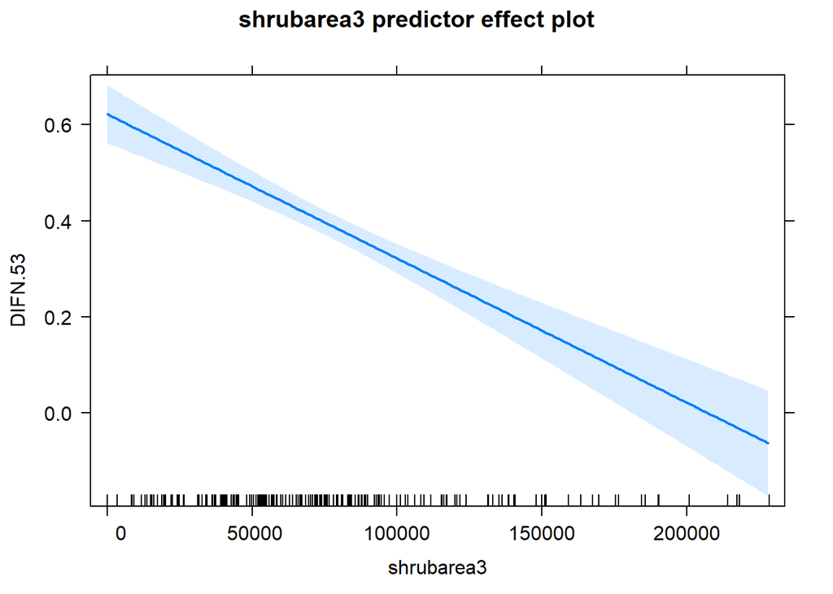

```r
plot(predictorEffect("shrubarea3", LM))
```

```r
shr_spp_effects <- predictorEffect("ShrubSpp03", LM)
shr_spp_effects <- as.data.frame(c(shr_spp_effects[6], shr_spp_effects[5], shr_spp_effects[17], shr_spp_effects[18]))
shr_spp_effects <- shr_spp_effects[1:3,]
shr_spp_effects <- shr_spp_effects %>%
  mutate(ShrubSpp03 =
           case_when(
             ShrubSpp03 == "CEIN" ~ "Deerbrush",
             ShrubSpp03 == "CECO" ~ "Whitethorn",
             ShrubSpp03 == "ARPA" ~ "Manzanita"
           ))
```

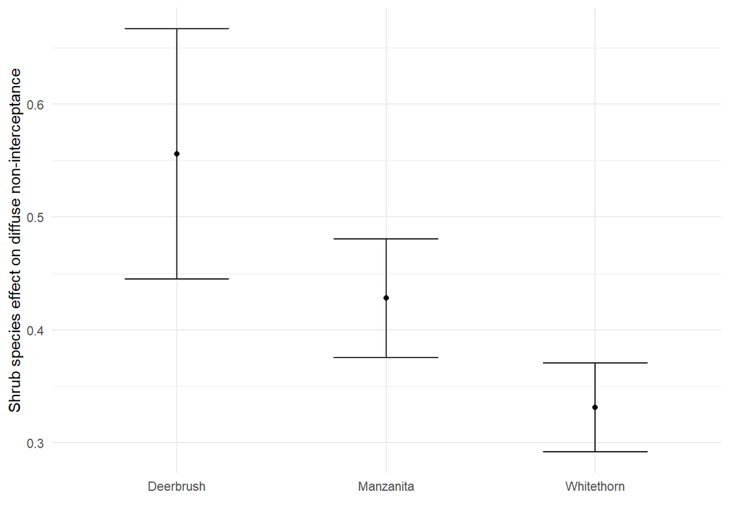

```r
ggplot(shr_spp_effects)+
  geom_point(aes(x = ShrubSpp03, y = fit))+
  geom_errorbar(aes(x = ShrubSpp03, ymin = lower, ymax = upper), width = 0.5)+
  ylab("Shrub species effect on diffuse non-interceptance")+
  theme_minimal()+
  xlab("")
```

```r
ggsave(file = "~/../Shrubs-Seedlings/results/figures/DIFN/DIFN_shr_spp_yrs.png", height = 4)
```

# Question 2: How does DIFN vary along the chronosequence with all species combined?

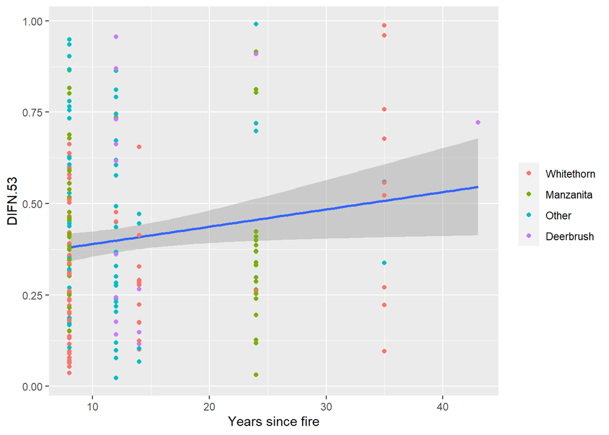

```r
ggplot(dfl_unique) +
  geom_smooth(aes(x = Years, y = DIFN.53), method = lm) +
  geom_point(aes(x = Years, y = DIFN.53, col = ShrubSpp03)) +
  xlab("Years since fire")+
  theme(legend.title = element_blank())
```

```r
ggsave("../../results/figures/DIFN/DIFN_years_lm.png")
```

# Question 3: Which is a better predictor of growth, DIFN or shrub characteristics?

Re-run the analyses in my fire foorprints code using DIFN instead of shrub cover and height

## Pines

For pines, that model is: VertGrowth_Rel ~ Ht_cm1 + Years + sqrt_shrubarea3 + heatload + ShrubSpp03 + BasDia2016.cm + Year + Ht_cm1:sqrt_shrubarea3

```r
load(file="../../compiled_data/fire_footprints/pine_vert_sim.Rdata")
df_pine <- df
```

### Subset data to those than have DIFN AND growth

```r
df_pine <- df %>% filter(!is.na(DIFN.53))
```

### Model with DIFN

```r
f <- VertGrowth_Rel ~ Ht_cm1 + Years + heatload + ShrubSpp03 + BasDia2016.cm + Year + DIFN.53 + Ht_cm1:DIFN.53
LM_pine_DIFN.53 <- lme(f, data = df_pine, random = ~1|Fire/FirePatch/Sdlg, method = "ML")
summary(LM_pine_DIFN.53)
```

```
## Linear mixed-effects model fit by maximum likelihood
##  Data: df_pine
##        AIC      BIC    logLik
##   340.7022 401.8691 -152.3511
##
## Random effects:
##  Formula: ~1 | Fire
##          (Intercept)
## StdDev: 1.853466e-05
##
##  Formula: ~1 | FirePatch %in% Fire
##         (Intercept)
## StdDev:   0.1417005
##
##  Formula: ~1 | Sdlg %in% FirePatch %in% Fire
##         (Intercept)  Residual
## StdDev:    0.211908 0.4315597
##
## Fixed effects: list(f)
##                      Value Std.Error  DF   t-value p-value
## (Intercept)      0.0182777 0.9473201 137  0.019294  0.9846
## Ht_cm1          -0.0140395 0.0022266 137 -6.305408  0.0000
## Years           -0.0558219 0.0144833 137 -3.854228  0.0002
## heatload        -0.7863074 0.8517887  58 -0.923125  0.3598
## ShrubSpp03CECO   0.1795451 0.1449870  58  1.238353  0.2206
## ShrubSpp03CEIN  -0.0485814 0.1832007  58 -0.265181  0.7918
## ShrubSpp03CHFO   0.1058135 0.2128906  58  0.497032  0.6210
## ShrubSpp03LIDE  -0.0038550 0.1650852  58 -0.023352  0.9814
## ShrubSpp03Other  0.2217809 0.2230293  58  0.994403  0.3242
## BasDia2016.cm    0.2518550 0.0529068  58  4.760352  0.0000
## Year2016         0.2211234 0.0757217 137  2.920212  0.0041
## Year2017        -0.0594245 0.0872451 137 -0.681121  0.4969
## DIFN.53         -0.5971323 0.2597511  58 -2.298864  0.0251
## Ht_cm1:DIFN.53   0.0053156 0.0022982 137  2.312970  0.0222
##  Correlation:
##                 (Intr) Ht_cm1 Years  heatld SS03CEC SS03CEI SS03CH SS03LI
## Ht_cm1          -0.115
## Years           -0.764 -0.105
## heatload        -0.975  0.064  0.693
## ShrubSpp03CECO  -0.176  0.044  0.149  0.088
```

[output cut: 19 more lines]

```
## Year2016         0.029  0.208
## Year2017         0.039  0.411  0.534
## DIFN.53          0.015 -0.096 -0.047 -0.092
## Ht_cm1:DIFN.53  -0.002 -0.033  0.033  0.069 -0.768
##
## Standardized Within-Group Residuals:
##        Min         Q1        Med         Q3        Max
## -3.9153943 -0.4742184  0.1077253  0.5157556  3.8141270
##
## Number of Observations: 221
## Number of Groups:
##                          Fire           FirePatch %in% Fire
##                             5                            13
## Sdlg %in% FirePatch %in% Fire
##                            79
```

Pseudo R2 of DIFN:

```r
pseudo_R2_DIFN <- r.squaredGLMM(LM_pine_DIFN.53)
pseudo_R2_DIFN
```

```
##            R2m       R2c
## [1,] 0.5774737 0.6867668
```

### Model with shrub cover and height

```r
f <- VertGrowth_Rel ~ Ht_cm1 + Years + heatload + ShrubSpp03 + BasDia2016.cm + Year + sqrt_shrubarea3 + Ht_cm1:sqrt_shrubarea3
LM_pine_shrubs <- lme(f, data = df_pine, random = ~1|Fire/FirePatch/Sdlg, method = "ML")
summary(LM_pine_shrubs)
```

```
## Linear mixed-effects model fit by maximum likelihood
##  Data: df_pine
##        AIC      BIC    logLik
##   327.0284 388.1953 -145.5142
##
## Random effects:
##  Formula: ~1 | Fire
##         (Intercept)
## StdDev:  1.1049e-05
##
##  Formula: ~1 | FirePatch %in% Fire
##         (Intercept)
## StdDev: 7.55927e-06
##
##  Formula: ~1 | Sdlg %in% FirePatch %in% Fire
##         (Intercept)  Residual
## StdDev:   0.1958085 0.4311167
##
## Fixed effects: list(f)
##                             Value Std.Error  DF   t-value p-value
## (Intercept)             0.2390655 0.8464215 137  0.282443  0.7780
## Ht_cm1                 -0.0165406 0.0041209 137 -4.013831  0.0001
## Years                  -0.0412176 0.0127149 137 -3.241671  0.0015
## heatload               -0.5450305 0.7683394  58 -0.709362  0.4809
## ShrubSpp03CECO          0.2220641 0.1112314  58  1.996415  0.0506
## ShrubSpp03CEIN          0.2964583 0.1541372  58  1.923341  0.0594
## ShrubSpp03CHFO          0.0649565 0.1406685  58  0.461770  0.6460
## ShrubSpp03LIDE         -0.1607388 0.1518609  58 -1.058461  0.2942
## ShrubSpp03Other         0.1006609 0.1997149  58  0.504023  0.6162
## BasDia2016.cm           0.2313437 0.0607244  58  3.809729  0.0003
## Year2016                0.1972824 0.0768532 137  2.567004  0.0113
## Year2017               -0.1040403 0.0927457 137 -1.121780  0.2639
## sqrt_shrubarea3        -0.0035607 0.0007615  58 -4.675596  0.0000
## Ht_cm1:sqrt_shrubarea3  0.0000206 0.0000083 137  2.493994  0.0138
##  Correlation:
##                        (Intr) Ht_cm1 Years  heatld SS03CEC SS03CEI SS03CH
## Ht_cm1                 -0.081
## Years                  -0.740 -0.146
## heatload               -0.971  0.024  0.742
## ShrubSpp03CECO         -0.061 -0.207  0.222  0.013
```

[output cut: 19 more lines]

```
## Year2016               -0.026  0.045  0.280
## Year2017               -0.054  0.072  0.528  0.555
## sqrt_shrubarea3         0.278 -0.020 -0.079 -0.007 -0.023
## Ht_cm1:sqrt_shrubarea3 -0.113  0.046  0.485  0.170  0.324 -0.656
##
## Standardized Within-Group Residuals:
##         Min          Q1         Med          Q3         Max
## -3.80096961 -0.53978689  0.08710084  0.59032535  3.66245692
##
## Number of Observations: 221
## Number of Groups:
##                          Fire           FirePatch %in% Fire
##                             5                            13
## Sdlg %in% FirePatch %in% Fire
##                            79
```

Pseudo R2 of shrub model:

```r
pseudo_R2_shrubs <- r.squaredGLMM(LM_pine_shrubs)
pseudo_R2_shrubs
```

```
##            R2m       R2c
## [1,] 0.6173765 0.6828091
```

```r
pseudo_R2_DIFN
```

```
##            R2m       R2c
## [1,] 0.5774737 0.6867668
```

```r
AIC(LM_pine_DIFN.53)
```

```
## [1] 340.7022
```

```r
AIC(LM_pine_shrubs)
```

```
## [1] 327.0284
```

## Firs

For firs, that model is: VertGrowth_Rel ~ Years + heatload + incidrad + Ht_cm1 + sqrt_shrubarea3 + Slope.Deg. + Elevation + Ht_cm1:sqrt_shrubarea3

```r
load(file="../../compiled_data/fire_footprints/fir_vert.Rdata")
df_fir <- df
```

### Subset data to those than have DIFN AND growth

```r
df_fir <- df_fir %>% filter(!is.na(DIFN.53))
```

### Model with DIFN

```r
f <- VertGrowth_Rel ~ Years +
                      heatload +
                      incidrad +
                      Ht_cm1 +
                      DIFN.53 +
                      Slope.Deg +
                      Elevation +
                      Ht_cm1:DIFN.53
LM_fir_DIFN.53 <- lme(f, data = df_fir, random = ~1|Fire/FirePatch/Sdlg, method = "ML")
summary(LM_fir_DIFN.53)
```

```
## Linear mixed-effects model fit by maximum likelihood
##  Data: df_fir
##        AIC      BIC    logLik
##   580.5131 627.7189 -277.2566
##
## Random effects:
##  Formula: ~1 | Fire
##          (Intercept)
## StdDev: 1.348434e-05
##
##  Formula: ~1 | FirePatch %in% Fire
##          (Intercept)
## StdDev: 1.151158e-05
##
##  Formula: ~1 | Sdlg %in% FirePatch %in% Fire
##         (Intercept)  Residual
## StdDev:   0.3599593 0.5715645
##
## Fixed effects: list(f)
##                    Value Std.Error  DF   t-value p-value
## (Intercept)    -0.665825 1.1053297 166 -0.602377  0.5477
## Years          -0.022237 0.0143877 166 -1.545540  0.1241
## heatload        0.511807 1.4849001  96  0.344674  0.7311
## incidrad       -3.672176 1.2140993  96 -3.024610  0.0032
## Ht_cm1         -0.011173 0.0031197 166 -3.581543  0.0004
## DIFN.53        -0.405666 0.4700928  96 -0.862950  0.3903
## Slope.Deg      -0.037056 0.0118259  96 -3.133435  0.0023
## Elevation       0.001614 0.0005131  96  3.145929  0.0022
## Ht_cm1:DIFN.53  0.008870 0.0058678 166  1.511711  0.1325
##  Correlation:
##                (Intr) Years  heatld incdrd Ht_cm1 DIFN.5 Slp.Dg Elevtn
## Years          -0.647
## heatload       -0.801  0.747
## incidrad        0.428 -0.286 -0.729
## Ht_cm1         -0.192 -0.088  0.117 -0.082
## DIFN.53        -0.485  0.263  0.440 -0.405  0.501
## Slope.Deg       0.198 -0.199 -0.326  0.501  0.035 -0.218
## Elevation      -0.367 -0.153  0.209 -0.626  0.000  0.251 -0.508
## Ht_cm1:DIFN.53  0.434 -0.267 -0.358  0.310 -0.716 -0.832  0.177 -0.201
##
## Standardized Within-Group Residuals:
##        Min         Q1        Med         Q3        Max
## -5.3001121 -0.4333722  0.1010151  0.5552768  2.4480909
##
## Number of Observations: 279
## Number of Groups:
##                          Fire           FirePatch %in% Fire
##                             5                             9
## Sdlg %in% FirePatch %in% Fire
##                           110
```

Pseudo R2 of DIFN:

```r
pseudo_R2_DIFN <- r.squaredGLMM(LM_fir_DIFN.53)
pseudo_R2_DIFN
```

```
##            R2m       R2c
## [1,] 0.1826115 0.4147388
```

### Model with shrub cover and height

```r
f <- VertGrowth_Rel ~ Years +
                      heatload +
                      incidrad +
                      Ht_cm1 +
                      sqrt_shrubarea3 +
                      Slope.Deg +
                      Elevation +
                      Ht_cm1:sqrt_shrubarea3
LM_fir_shrubs <- lme(f, data = df_fir, random = ~1|Fire/FirePatch/Sdlg, method = "ML")
summary(LM_fir_shrubs)
```

```
## Linear mixed-effects model fit by maximum likelihood
##  Data: df_fir
##        AIC     BIC    logLik
##   583.3372 630.543 -278.6686
##
## Random effects:
##  Formula: ~1 | Fire
##          (Intercept)
## StdDev: 1.353582e-05
##
##  Formula: ~1 | FirePatch %in% Fire
##          (Intercept)
## StdDev: 1.176352e-05
##
##  Formula: ~1 | Sdlg %in% FirePatch %in% Fire
##         (Intercept) Residual
## StdDev:   0.3552584 0.576906
##
## Fixed effects: list(f)
##                            Value Std.Error  DF   t-value p-value
## (Intercept)            -1.255097 1.0198187 166 -1.230705  0.2202
## Years                  -0.018197 0.0157646 166 -1.154310  0.2500
## heatload                0.994512 1.4262651  96  0.697284  0.4873
## incidrad               -3.985105 1.1308101  96 -3.524115  0.0007
## Ht_cm1                 -0.007337 0.0063145 166 -1.161898  0.2469
## sqrt_shrubarea3         0.000149 0.0016799  96  0.088954  0.9293
## Slope.Deg              -0.039208 0.0115257  96 -3.401768  0.0010
## Elevation               0.001732 0.0005178  96  3.345501  0.0012
## Ht_cm1:sqrt_shrubarea3  0.000000 0.0000207 166  0.005259  0.9958
##  Correlation:
##                        (Intr) Years  heatld incdrd Ht_cm1 sqrt_3 Slp.Dg Elevtn
## Years                  -0.362
## heatload               -0.546  0.769
## incidrad                0.204 -0.267 -0.684
## Ht_cm1                 -0.228 -0.390 -0.298  0.224
## sqrt_shrubarea3        -0.330 -0.446 -0.352  0.204  0.809
## Slope.Deg               0.111 -0.114 -0.233  0.448  0.063 -0.028
## Elevation              -0.340 -0.334  0.005 -0.509  0.057  0.239 -0.471
## Ht_cm1:sqrt_shrubarea3  0.283  0.276  0.258 -0.182 -0.942 -0.844  0.007 -0.115
##
## Standardized Within-Group Residuals:
##         Min          Q1         Med          Q3         Max
## -5.37518987 -0.41627414  0.04940376  0.56689315  2.53393944
##
## Number of Observations: 279
## Number of Groups:
##                          Fire           FirePatch %in% Fire
##                             5                             9
## Sdlg %in% FirePatch %in% Fire
##                           110
```

Pseudo R2 of shrub model:

```r
pseudo_R2_shrubs <- r.squaredGLMM(LM_fir_shrubs)
pseudo_R2_shrubs
```

```
##            R2m       R2c
## [1,] 0.1721217 0.3997441
```

```r
pseudo_R2_DIFN
```

```
##            R2m       R2c
## [1,] 0.1826115 0.4147388
```

```r
AIC(LM_fir_DIFN.53)
```

```
## [1] 580.5131
```

```r
AIC(LM_fir_shrubs)
```

```
## [1] 583.3372
```